# Project

## Logistic Regression

```r
library(dplyr)
library(pROC)
library(ggplot2)
library(ggpubr)
library(caret)

data(iris)

# Convert the species to binary classes
iris$Species_Binary <- ifelse(iris$Species == "setosa", 1, 0)

# Split the data into training and testing sets
set.seed(123)
train_indices <- sample(1:nrow(iris), 0.7 * nrow(iris))  # 70% for training, 30% for testing
train_data <- iris[train_indices, ]
test_data <- iris[-train_indices, ]

# logistic regression on the training set
logit_model <- glm(Species_Binary ~ Sepal.Length + Sepal.Width + Petal.Length + Petal.Width,
                   data = train_data,
                   family = binomial)

# Summary of the logistic regression model
summary(logit_model)
```

```
##
## Call:
## glm(formula = Species_Binary ~ Sepal.Length + Sepal.Width + Petal.Length +
##     Petal.Width, family = binomial, data = train_data)
##
## Coefficients:
##                Estimate Std. Error z value Pr(>|z|)
## (Intercept)     -18.220 540630.067       0        1
## Sepal.Length     12.295 152119.433       0        1
## Sepal.Width       7.802  70088.696       0        1
## Petal.Length    -20.558 124693.215       0        1
## Petal.Width     -21.938 178623.820       0        1
##
## (Dispersion parameter for binomial family taken to be 1)
##
##     Null deviance: 1.3501e+02  on 104  degrees of freedom
## Residual deviance: 2.3265e-09  on 100  degrees of freedom
## AIC: 10
##
## Number of Fisher Scoring iterations: 25
```

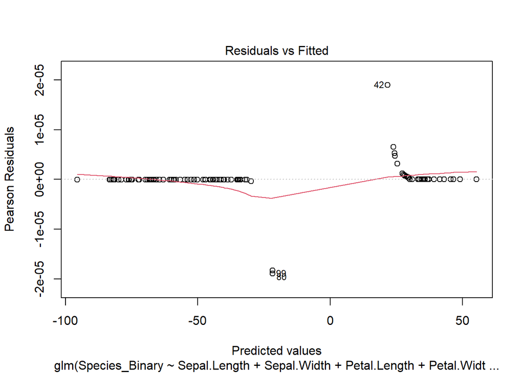

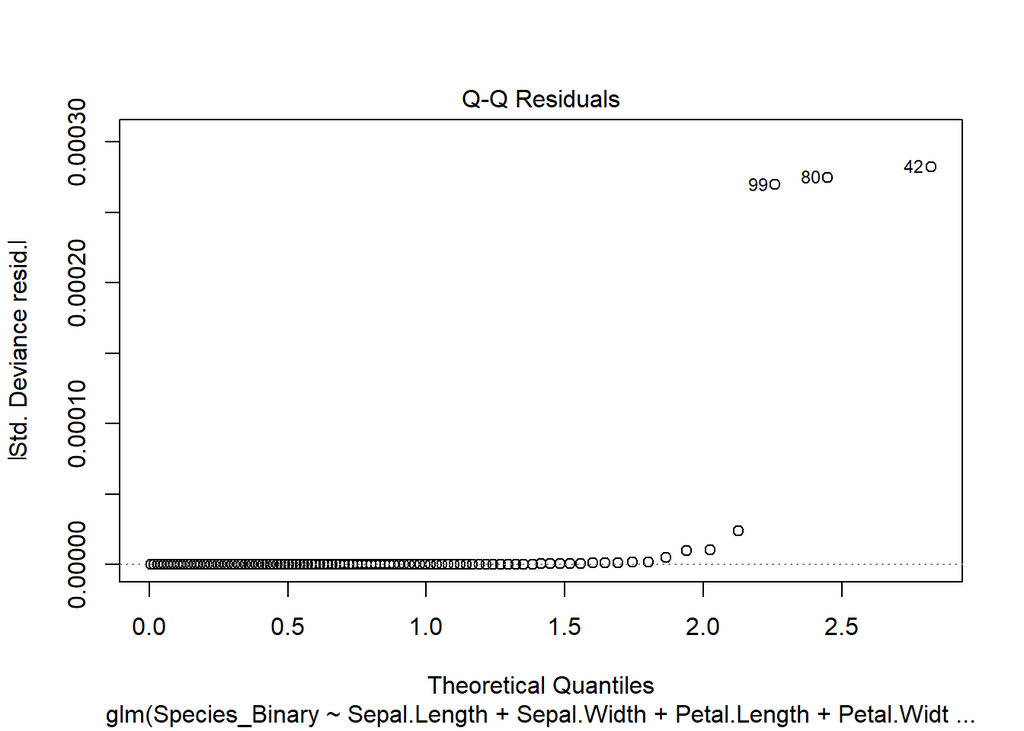

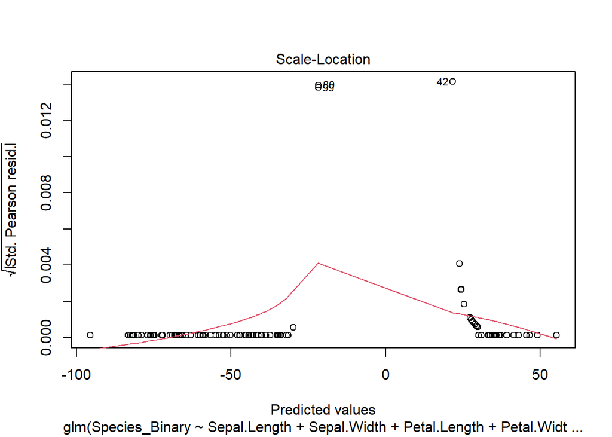

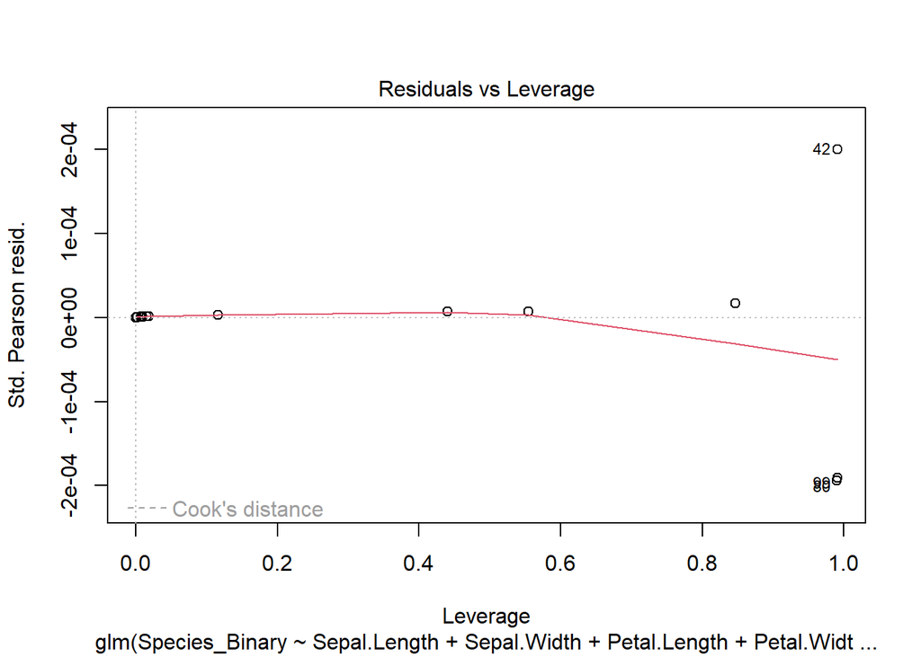

```r
# Residual Analysis
plot(logit_model)
```

```r
# probabilities on the testing set
predicted_prob <- predict(logit_model, newdata = test_data, type = "response")

threshold <- 0.5
predicted_binary <- ifelse(predicted_prob > threshold, 1, 0)

# Model evaluation on the testing set
confusion <- table(predicted_binary, test_data$Species_Binary)
accuracy <- sum(diag(confusion)) / sum(confusion)
precision <- confusion[2, 2] / sum(confusion[, 2])
recall <- confusion[2, 2] / sum(confusion[2, ])
f1_score <- 2 * precision * recall / (precision + recall)
auc <- roc(test_data$Species_Binary, predicted_prob)$auc

# Model Accuracy
cat("Accuracy:", accuracy, "\n")
```

```
## Accuracy: 1
```

```r
# other evaluation metrics
cat("Precision:", precision, "\n")
```

```
## Precision: 1
```

```r
cat("Recall:", recall, "\n")
```

```
## Recall: 1
```

```r
cat("F1-score:", f1_score, "\n")
```

```
## F1-score: 1
```

```r
cat("AUC:", auc, "\n")
```

```
## AUC: 1
```

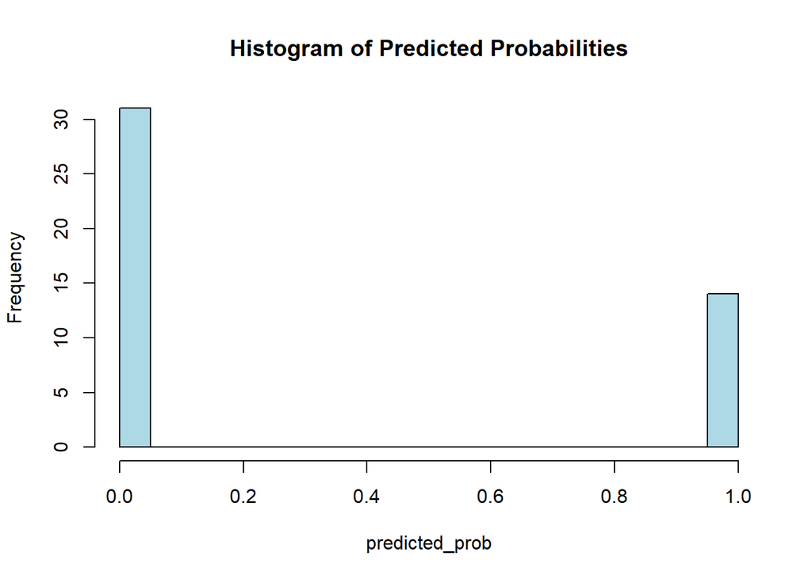

```r
# Visualization of Probabilities
hist(predicted_prob, breaks = 20, col = "lightblue", main = "Histogram of Predicted Probabilities")
```

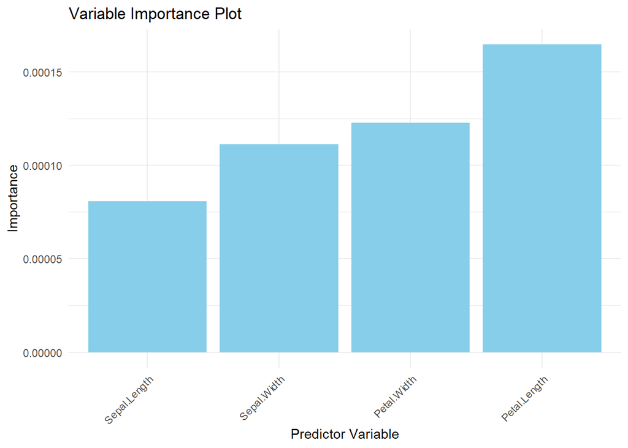

```r
# Variable Importance Plot
var_importance <- varImp(logit_model)
ggplot(var_importance, aes(x = reorder(rownames(var_importance), Overall), y = Overall)) +
  geom_bar(stat = "identity", fill = "skyblue") +
  labs(title = "Variable Importance Plot", x = "Predictor Variable", y = "Importance") +
  theme_minimal() +
  theme(axis.text.x = element_text(angle = 45, hjust = 1))
```

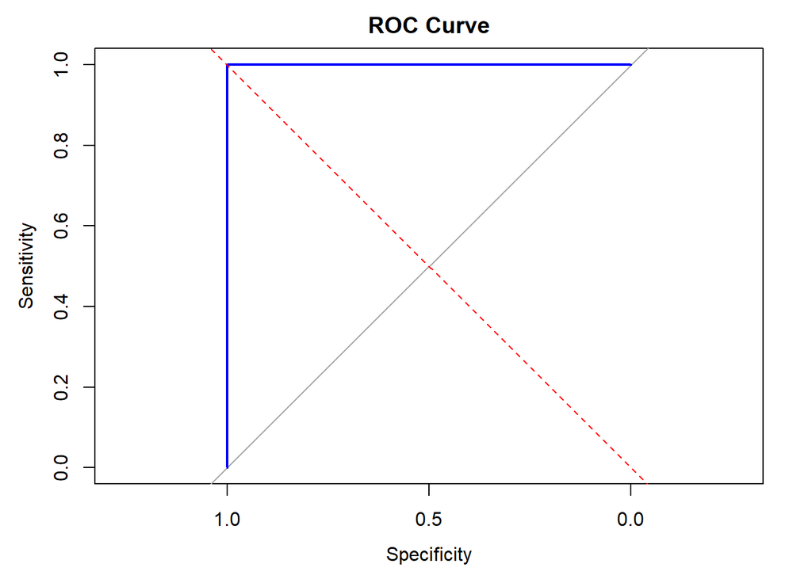

```r
# ROC Curve
roc_curve <- roc(test_data$Species_Binary, predicted_prob)
plot(roc_curve, main = "ROC Curve", col = "blue", lwd = 2)
abline(a = 0, b = 1, lty = 2, col = "red")
```

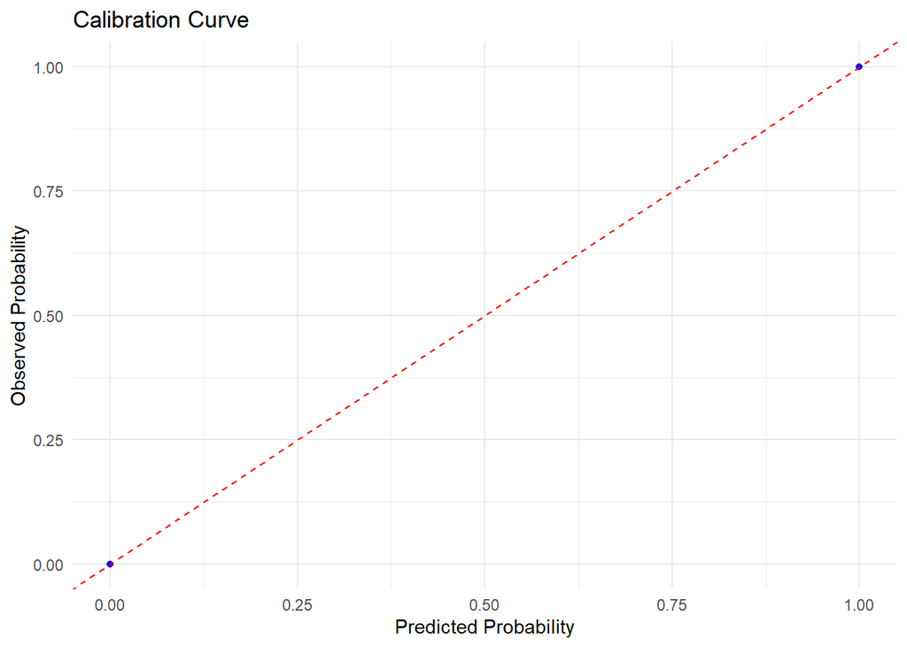

```r
# Calibration Curve
calibration <- data.frame(Observed = test_data$Species_Binary, Predicted = predicted_prob)
ggplot(calibration, aes(x = Predicted, y = Observed)) +
  geom_point(color = "blue") +
  geom_abline(intercept = 0, slope = 1, linetype = "dashed", color = "red") +
  labs(title = "Calibration Curve", x = "Predicted Probability", y = "Observed Probability") +
  theme_minimal()
```

## Discriminant analysis

```r
library(MASS)
library(ROCR)

data(iris)
```

### Model Development

Linear Discriminant Analysis (LDA) is performed on the dataset using the lda() function from the MASS package. LDA is a statistical method used for dimensionality reduction and classification. Here, the model is trained to predict the species of iris flowers based on their measurements.

### Prediction

The trained LDA model is used to make predictions on the same dataset (iris) using the predict() function. This step generates predictions for each observation in the dataset, including the predicted class and posterior probabilities.

```r
# LDA
lda_model <- lda(Species ~ ., data = iris)

lda_predictions <- predict(lda_model, newdata = iris)
lda_predictions
```

```
## $class
##   [1] setosa     setosa     setosa     setosa     setosa     setosa
##   [7] setosa     setosa     setosa     setosa     setosa     setosa
##  [13] setosa     setosa     setosa     setosa     setosa     setosa
##  [19] setosa     setosa     setosa     setosa     setosa     setosa
##  [25] setosa     setosa     setosa     setosa     setosa     setosa
##  [31] setosa     setosa     setosa     setosa     setosa     setosa
##  [37] setosa     setosa     setosa     setosa     setosa     setosa
##  [43] setosa     setosa     setosa     setosa     setosa     setosa
##  [49] setosa     setosa     versicolor versicolor versicolor versicolor
##  [55] versicolor versicolor versicolor versicolor versicolor versicolor
##  [61] versicolor versicolor versicolor versicolor versicolor versicolor
##  [67] versicolor versicolor versicolor versicolor virginica  versicolor
##  [73] versicolor versicolor versicolor versicolor versicolor versicolor
##  [79] versicolor versicolor versicolor versicolor versicolor virginica
```

[output cut: 318 more lines]

```r
# predicted classes
predicted_classes <- lda_predictions$class
predicted_classes
```

```
##   [1] setosa     setosa     setosa     setosa     setosa     setosa
##   [7] setosa     setosa     setosa     setosa     setosa     setosa
##  [13] setosa     setosa     setosa     setosa     setosa     setosa
##  [19] setosa     setosa     setosa     setosa     setosa     setosa
##  [25] setosa     setosa     setosa     setosa     setosa     setosa
##  [31] setosa     setosa     setosa     setosa     setosa     setosa
##  [37] setosa     setosa     setosa     setosa     setosa     setosa
##  [43] setosa     setosa     setosa     setosa     setosa     setosa
##  [49] setosa     setosa     versicolor versicolor versicolor versicolor
##  [55] versicolor versicolor versicolor versicolor versicolor versicolor
##  [61] versicolor versicolor versicolor versicolor versicolor versicolor
##  [67] versicolor versicolor versicolor versicolor virginica  versicolor
##  [73] versicolor versicolor versicolor versicolor versicolor versicolor
##  [79] versicolor versicolor versicolor versicolor versicolor virginica
##  [85] versicolor versicolor versicolor versicolor versicolor versicolor
##  [91] versicolor versicolor versicolor versicolor versicolor versicolor
##  [97] versicolor versicolor versicolor versicolor virginica  virginica
## [103] virginica  virginica  virginica  virginica  virginica  virginica
## [109] virginica  virginica  virginica  virginica  virginica  virginica
## [115] virginica  virginica  virginica  virginica  virginica  virginica
## [121] virginica  virginica  virginica  virginica  virginica  virginica
## [127] virginica  virginica  virginica  virginica  virginica  virginica
## [133] virginica  versicolor virginica  virginica  virginica  virginica
## [139] virginica  virginica  virginica  virginica  virginica  virginica
## [145] virginica  virginica  virginica  virginica  virginica  virginica
## Levels: setosa versicolor virginica
```

### Model Evaluation

The accuracy of the model is calculated by comparing the predicted classes with the actual classes in the dataset. This gives an indication of how well the model performs in classifying iris flowers into their respective species.

```r
# Calculate accuracy
accuracy <- mean(predicted_classes == iris$Species)

# Summary of the LDA model and accuracy
cat("Summary of LDA Model:\n")
```

```
## Summary of LDA Model:
```

```r
print(summary(lda_model))
```

```
##         Length Class  Mode
## prior    3     -none- numeric
## counts   3     -none- numeric
## means   12     -none- numeric
## scaling  8     -none- numeric
## lev      3     -none- character
## svd      2     -none- numeric
## N        1     -none- numeric
## call     3     -none- call
## terms    3     terms  call
## xlevels  0     -none- list
```

```r
print(lda_model)
```

```
## Call:
## lda(Species ~ ., data = iris)
##
## Prior probabilities of groups:
##     setosa versicolor  virginica
##  0.3333333  0.3333333  0.3333333
##
## Group means:
##            Sepal.Length Sepal.Width Petal.Length Petal.Width
## setosa            5.006       3.428        1.462       0.246
## versicolor        5.936       2.770        4.260       1.326
## virginica         6.588       2.974        5.552       2.026
##
## Coefficients of linear discriminants:
##                     LD1         LD2
## Sepal.Length  0.8293776 -0.02410215
## Sepal.Width   1.5344731 -2.16452123
## Petal.Length -2.2012117  0.93192121
## Petal.Width  -2.8104603 -2.83918785
##
## Proportion of trace:
##    LD1    LD2
## 0.9912 0.0088
```

```r
cat("\nModel Accuracy:", round(accuracy * 100, 2), "%\n")
```

```
##
## Model Accuracy: 98 %
```

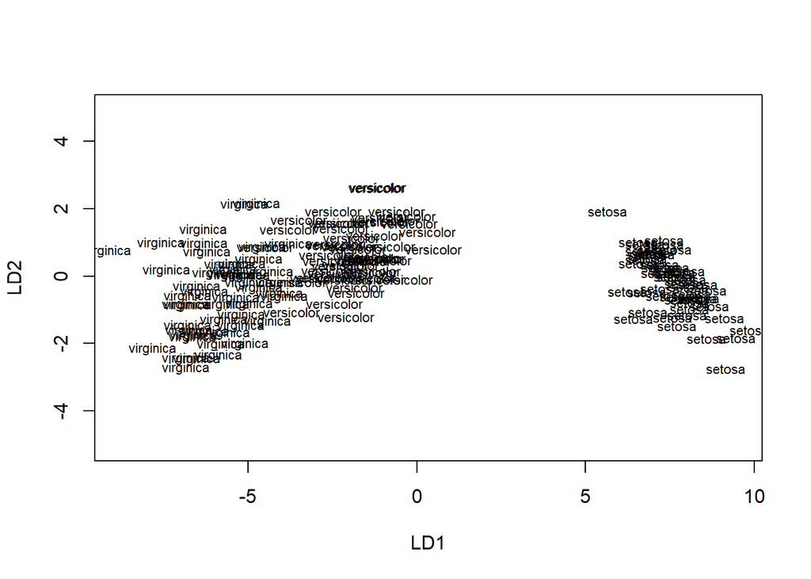

```r
plot(lda_model)
```

```r
# discriminant scores
lda_scores <- lda_predictions$x
lda_scores
```

```
##            LD1          LD2
## 1    8.0617998 -0.300420621
## 2    7.1286877  0.786660426
## 3    7.4898280  0.265384488
## 4    6.8132006  0.670631068
## 5    8.1323093 -0.514462530
## 6    7.7019467 -1.461720967
## 7    7.2126176 -0.355836209
## 8    7.6052935  0.011633838
## 9    6.5605516  1.015163624
## 10   7.3430599  0.947319209
## 11   8.3973865 -0.647363392
## 12   7.2192969  0.109646389
## 13   7.3267960  1.072989426
## 14   7.5724707  0.805464137
```

[output cut: 136 more lines]

```r
# Convert the predicted probabilities to a data frame
predicted_probabilities <- as.data.frame(lda_predictions$posterior)
predicted_probabilities
```

```
##           setosa   versicolor    virginica
## 1   1.000000e+00 3.896358e-22 2.611168e-42
## 2   1.000000e+00 7.217970e-18 5.042143e-37
## 3   1.000000e+00 1.463849e-19 4.675932e-39
## 4   1.000000e+00 1.268536e-16 3.566610e-35
## 5   1.000000e+00 1.637387e-22 1.082605e-42
## 6   1.000000e+00 3.883282e-21 4.566540e-40
## 7   1.000000e+00 1.113469e-18 2.302608e-37
## 8   1.000000e+00 3.877586e-20 1.074496e-39
## 9   1.000000e+00 1.902813e-15 9.482936e-34
## 10  1.000000e+00 1.111803e-18 2.724060e-38
## 11  1.000000e+00 1.185277e-23 3.237084e-44
## 12  1.000000e+00 1.621649e-18 1.833201e-37
## 13  1.000000e+00 1.459225e-18 3.262506e-38
## 14  1.000000e+00 1.117219e-19 1.316642e-39
```

[output cut: 136 more lines]

### Model Accuracy

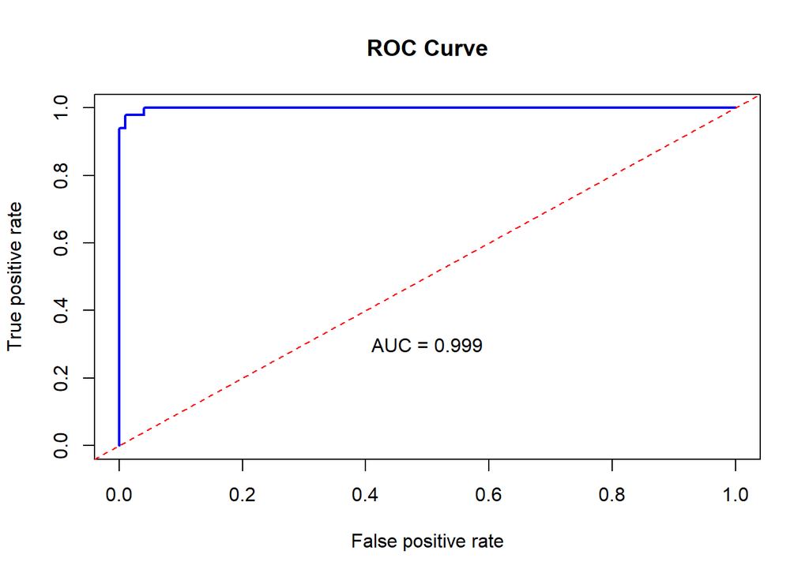

```r
pred <- prediction(predicted_probabilities[, "versicolor"], iris$Species == "versicolor")

roc.perf <- performance(pred, measure = "tpr", x.measure = "fpr")

auc.train <- performance(pred, measure = "auc")@y.values[[1]]

# ROC curve
plot(roc.perf, main = "ROC Curve", col = "blue", lwd = 2)
abline(a = 0, b = 1, lty = 2, col = "red")
text(x = 0.5, y = 0.3, paste("AUC = ", round(auc.train, 3), sep = ""))
```